# Equivalency Between GARCH and RNN

Author

Hisyam Maheswara Kusuma Saputro

# Introduction

Volatility modeling is a foundational component of modern financial modeling, mostly executed using econometrics. This project explores the concept of interpretability within Neural Network, explicitly demonstrating how a Recurrent Neural Network (RNN) can be structurally constrained to mimic a GARCH model. By transitioning the neural network from a black-box model into an interpretable statistical model, the model can preserve full interpretability while leveraging the computational scalability of neural network.

# Models and Equivalency

## GARCH

Given GARCH(1,1) model, which portrays conditional variance as a linear combination of past squared innovations and past conditional variance.

$$\sigma^2_t=\omega+\alpha\varepsilon^2_{t-1}+\beta\sigma^2_{t-1}$$

To preserve convergency, the parameters is strictly constrained to prevent negative variance and ensure covariance stationarity:

1. Non-negativity: $\omega > 0$, $\alpha \ge 0$, $\beta \ge 0$
2. Stationarity: $\alpha + \beta < 1$

## Recurrent Neural Network and Equivalency

A standard Recurrent Neural Network with a single hidden state $h_t$ is defined by,

$$\begin{align}
h_t&=f(W_hh_{t-1}+W_xX_t+bias_1)\\
y_t&=W_yh_t+bias_2
\end{align}$$

where mathematical equivalency between GARCH and RNN is achieved by applying these constraints:

- Set the activation function $f(x)$ to identity function $\left(f(x)=x\right)$.
- Force $W_y=1$ and $bias_2=0$.
- Map the input $\varepsilon^2_{t-1}\to X_t$.

To enforce GARCH constraints onto the equivalent RNN model, the parameters are mapped such as:

- $\omega= \ln{\left(1+e^{\omega_{raw}}\right)}$ (Ensures $\omega>0$)
- To guarantee $\alpha+\beta<1$ dynamically:
  $$\begin{align}
  \text{sum}_{parameters} &= \text{Sigmoid}(\alpha_{raw})\times0.999 \\
  \text{ratio} &= \text{Sigmoid}(\beta_{raw}) \\
  \alpha &= \text{sum}_{parameters} \times (1 - \text{ratio}) \\
  \beta &= \text{sum}_{parameters} \times \text{ratio}
  \end{align}$$

# Library & Dataset

For this project, the used library is:

```python
# Essential Library
import random
import numpy as np
import pandas as pd
import matplotlib.pyplot as plt
from scipy.stats import norm

# GARCH library
from arch import arch_model

# RNN Library
import torch
import torch.nn as nn
import torch.optim as optim
```

Using XRP historical data from June 2019 until May 2026, using 2556 day trading in total. Daily log return is multiplied by 100 for numerical stability purpose.

```
            Date  Price   Open   High    Low      Vol  Return
0     01/06/2019   4289   4384   4412   4196    1.47B -0.0216
1     02/06/2019   4440   4289   4466   4279    1.25B  0.0346
2     03/06/2019   4180   4440   4634   4180    2.38B -0.0603
3     04/06/2019   3984   4181   4188   3853    2.44B  -0.048
4     05/06/2019   4004   3984   4056   3882    1.62B   0.005
...          ...    ...    ...    ...    ...      ...     ...
2551  27/05/2026  13074  13302  13418  13032  231.50M -0.0161
2552  28/05/2026  13152  13083  13375  12687  332.95M  0.0059
2553  29/05/2026  13295  13152  13324  12950  303.71M  0.0108
2554  30/05/2026  13400  13294  13646  13278  228.10M  0.0079
2555  31/05/2026  13327  13400  13477  13215  139.56M -0.0055
```

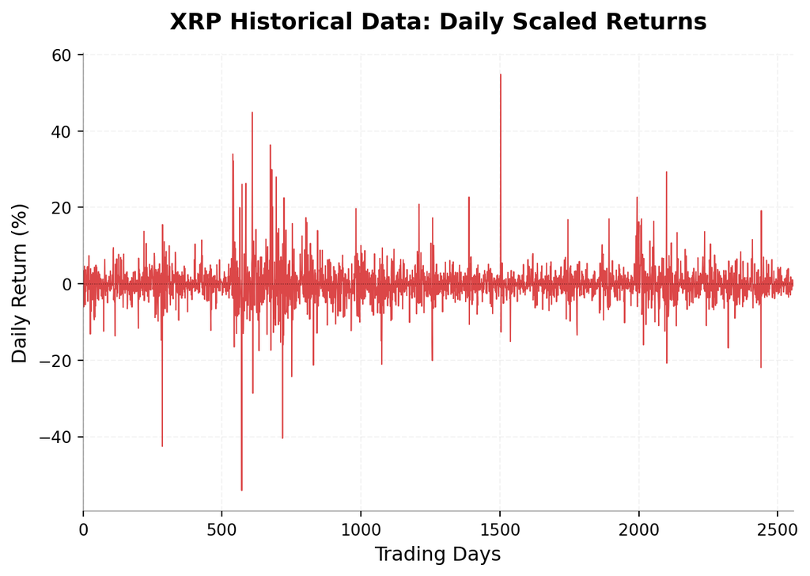

From the time series plot, it’s apparent that XRP has high density volatility clustering and some extreme price change.

# Model Fitting

## GARCH (using MLE)

Using standard GARCH(1, 1) model from `arch` library, the parameter is estimated via Maximum Likelihood Estimation with zero mean model and using normal distribution.

```python
am = arch_model(returns, vol="GARCH", p = 1, q = 1, mean = "Zero", dist="normal")
res = am.fit()
res.summary()
```

```
Iteration:      1,   Func. Count:      5,   Neg. LLF: 15408.053318903017
Iteration:      2,   Func. Count:     11,   Neg. LLF: 7694.7248386060855
Iteration:      3,   Func. Count:     16,   Neg. LLF: 7650.103866598076
Iteration:      4,   Func. Count:     22,   Neg. LLF: 7881.109817832647
Iteration:      5,   Func. Count:     27,   Neg. LLF: 7503.1221093872155
Iteration:      6,   Func. Count:     31,   Neg. LLF: 7503.118467201548
Iteration:      7,   Func. Count:     35,   Neg. LLF: 7503.1183707287655
Iteration:      8,   Func. Count:     38,   Neg. LLF: 7503.118370727706
Optimization terminated successfully    (Exit mode 0)
            Current function value: 7503.1183707287655
            Iterations: 8
            Function evaluations: 38
            Gradient evaluations: 8
```

Zero Mean - GARCH Model Results

| Dep. Variable: | Return | R-squared: | 0.000 |
| --- | --- | --- | --- |
| Mean Model: | Zero Mean | Adj. R-squared: | 0.000 |
| Vol Model: | GARCH | Log-Likelihood: | -7503.12 |
| Distribution: | Normal | AIC: | 15012.2 |
| Method: | Maximum Likelihood | BIC: | 15029.8 |
|  |  | No. Observations: | 2556 |
| Date: | Tue, Oct 06 2026 | Df Residuals: | 2556 |
| Time: | 14:28:08 | Df Model: | 0 |

Volatility Model

|  | coef | std err | t | P>\|t\| | 95.0% Conf. Int. |
| --- | --- | --- | --- | --- | --- |
| omega | 3.7213 | 2.208 | 1.685 | 9.196e-02 | [ -0.607, 8.050] |
| alpha[1] | 0.2804 | 0.103 | 2.711 | 6.708e-03 | [7.768e-02, 0.483] |
| beta[1] | 0.6271 | 0.116 | 5.411 | 6.256e-08 | [ 0.400, 0.854] |

Covariance estimator: robust

The optimization converges on the following conditional variance specification:

$$\sigma^2_t=3.7213+0.2804\varepsilon^2_{t-1}+0.6271\sigma^2_{t-1}$$

The long-run persistence of the volatility is calculated to evaluate the memory decay rate of market shocks:

$$\alpha+\beta=0.280376+0.627134=0.907510$$

## RNN

The structure of the RNN is given as follows, built using PyTorch.

```python
# For reproducibility
random.seed(69420)

# For random initial values
s = random.uniform(0.5, 0.98)
r = random.uniform(0.1, 0.9)

class GARCHRNN(nn.Module):
    def __init__(self):
        super(GARCHRNN, self).__init__()

        # Parameters initialization
        self.omega_raw = nn.Parameter(torch.tensor([0.01]))
        self.alpha_raw = nn.Parameter(torch.tensor([s * r]))
        self.beta_raw = nn.Parameter(torch.tensor([s * (1 - r)]))

    # Forward pass
    def forward(self, eps_sq):
        n_t = eps_sq.size(0)

        # Parameters constraints
        w = torch.log(1 + torch.exp(self.omega_raw))
        sum_param = torch.sigmoid(self.alpha_raw) * 0.999
        ratio = torch.sigmoid(self.beta_raw)
        a = sum_param * (1 - ratio)
        b = sum_param * ratio

        # Initializing first hidden state value
        h = []
        h.append(w / (1 - a - b + 1e-6))

        # Custom loop
        for t in range(1, n_t):
            h_t = w + a * eps_sq[t - 1] + b * h[t - 1]
            h.append(h_t)

        return torch.stack(h)
```

The model is trained using Adam optimizer with 512 epochs, using negative log-likelihood from GARCH model as the loss function.

```python
epsilon_sq_np = np.array(returns ** 2, dtype = np.float32)
epsilon_sq_tensor = torch.tensor(epsilon_sq_np, dtype = torch.float32).view(-1, 1)

# Custom loss function (Negative Log-Likelihood)
def nll(h, eps_sq):
    return torch.mean(torch.log(h) + (eps_sq / h))

# Model training phase
torch.manual_seed(69420)
model = GARCHRNN()
optimizer = optim.Adam(model.parameters(), lr = 0.01)

epochs = 512
loss_history = []

print("Starting optimization loop...")
for epoch in range(epochs):
    optimizer.zero_grad()
    h_t = model(epsilon_sq_tensor)
    loss = nll(h_t, epsilon_sq_tensor)
    loss.backward()
    optimizer.step()
    loss_history.append(loss.item())

    if (epoch + 1) % 64 == 0 or epoch == 0:
        print(f"Epoch {epoch+1:03d}/{epochs} | Negative Log-Likelihood: {loss.item():.5f}")

print("\nOptimization complete.")
```

[output not shown]

The optimization converges on the following conditional variance specification:

$$\sigma^2_t=1.985587+0.125141\varepsilon^2_{t-1}+0.776272\sigma^2_{t-1}$$

The long-run persistence of the volatility is calculated to evaluate the memory decay rate of market shocks:

$$\alpha+\beta=0.125141+0.776272=0.901413$$

The loss plot shows a smooth asymptotic minimization of the loss function, confirming stable convergence during training phase.

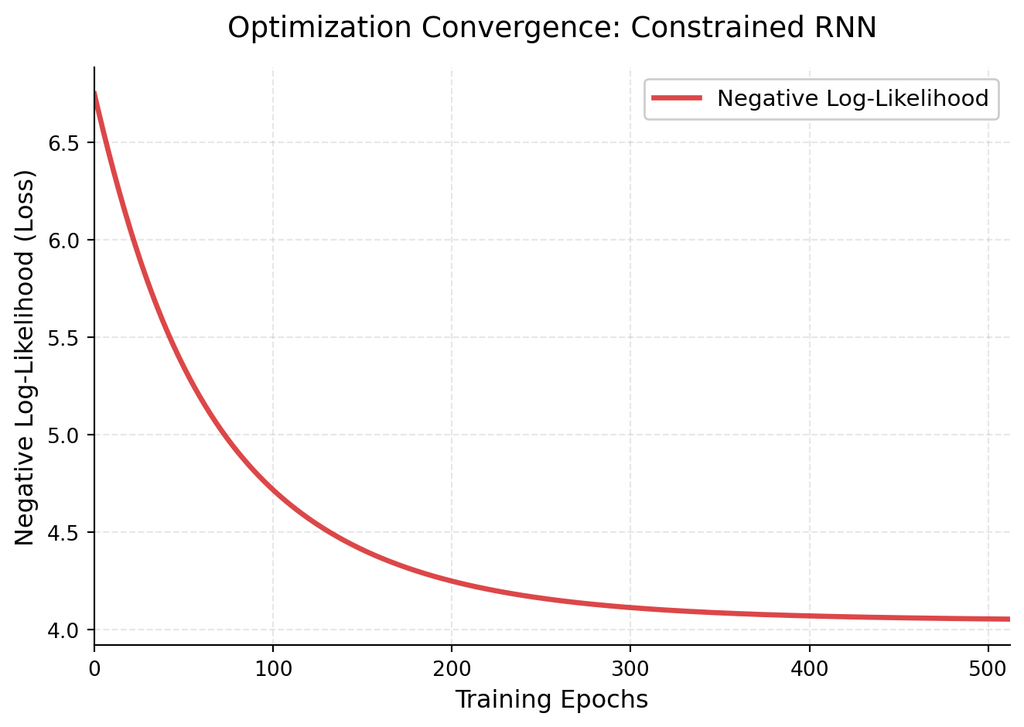

# Model Comparison

```
------------- Models Convergence Results -------------
              Parameter  GARCH via MLE (arch)      RNN
           Omega (Bias)              3.721306 1.985587
   Alpha (Input Weight)              0.280376 0.125141
Beta (Recurrent Weight)              0.627134 0.776272
```

A key finding is that RNN model has lower immediate shock response ($\alpha=0.125...$) and higher memory ($\beta=0.776...$) relative to standard GARCH. Both model has almost identical total volatility persistence ($\alpha+\beta\approx0.90$).

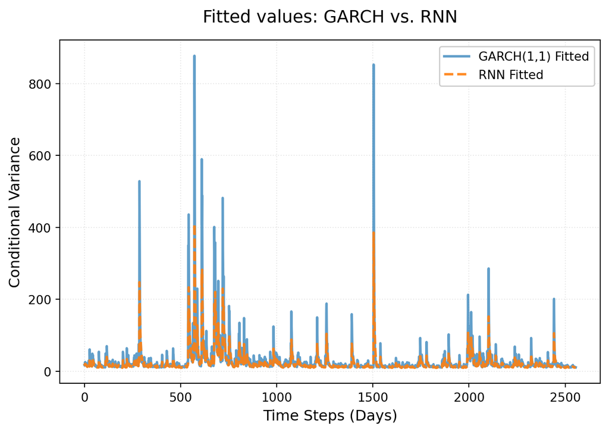

To validate the model’s utility, a Value-at-Risk (VaR) backtest was implemented at a 95% confidence level on upper and lower direction. This framework tracks both long risk (downside breach) and short risk (upside breach) across the 2,556-day evaluation period.

```
--------------- VaR Backtesting Result ---------------
Total Observations       :  2556 days
Expected Total Violation :  2 x 5% = 10.00% (256 days)
RNN Total Violations     :  200 (7.82%)
└───  Positive (Short)   :  103 (4.03%)
└───  Negative (Long)    :  97  (3.79%)
GARCH  Total Violations  :  173 (6.77%)
└───  Positive (Short)   :  88  (3.44%)
└───  Negative (Long)    :  85  (3.33%)
```

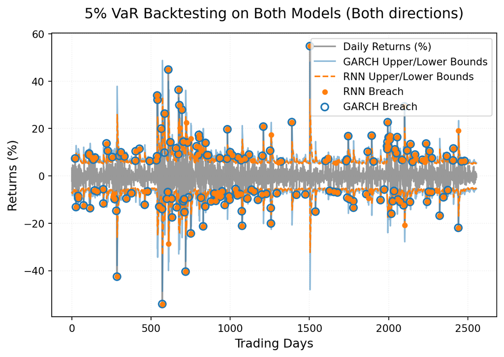

Model Evaluation & Volatility Analysis:

- Model Evaluation: The theoretical target for the combined bi-directional boundary is a 10.00% violation rate. The PyTorch RNN achieved 7.82%, outperforming the classical MLE baseline (6.77%) by tracking significantly closer to the true statistical specification.
- Volatility Portrayed by Both Models: The classical MLE model exhibits structural over-conservatism, generating wider risk envelopes that lock up unnecessary capital buffers. Because the RNN adapts more accurately along the local variance surface, it optimizes capital utilization without crossing the line into regulatory under-protection.
- Tail Asymmetry Insight: Both models show higher violation rates on positive returns compared to negative returns. This occurs because symmetric GARCH structures do not account for leverage transitions, meaning that aggressive upward shifts in cryptocurrency markets can compress lower boundary protections and expose short-side risk portfolios.

# Conclusion

This project successfully demonstrates that neural networks can be structurally bound to classical econometric models without losing their interpretability properties. The constrained RNN matches the core utility of traditional GARCH model while offering superior operational flexibility. For institutional risk applications, this architecture provides a reliable pathway to embed structural econometric priors directly into broad multi-asset deep learning pipelines.